# Vinko analysis commands run

# Test single sample D1

Kneaddata:

```bash
mkdir kneaddata_out
parallel -j 1 --link 'kneaddata -i {1} -i {2} -o kneaddata_out/ \
-db /home/shared/bowtiedb/GRCh38_PhiX --trimmomatic /home/robyn/tools/Trimmomatic-0.39/ \
-t 12 --trimmomatic-options "SLIDINGWINDOW:4:20 MINLEN:50" \
--bowtie2-options "--very-sensitive --dovetail" --remove-intermediate-output' \
 ::: D1/*1.fq.gz ::: D1/*2.fq.gz
```

```bash
mkdir kneaddata_out
parallel -j 1 --link 'kneaddata -i {1} -i {2} -o kneaddata_out/ \
-db /home/shared/bowtiedb/GRCh38_PhiX --trimmomatic /home/robyn/tools/Trimmomatic-0.39/ \
-t 12 --trimmomatic-options "SLIDINGWINDOW:4:20 MINLEN:50" \
--bowtie2-options "--very-sensitive --dovetail" --remove-intermediate-output' \
 ::: test/*1.fq.gz ::: test/*2.fq.gz
```

Join reads:

```bash
concat_paired_end.pl -p 4 -o cat_reads --no-R-match kneaddata_out/*paired*.fastq
```

```bash
mkdir kraken2_outraw
mkdir kraken2_kreport
parallel -j 1 'kraken2 --use-names --threads 12 --db /scratch/ramdisk/Kraken2.0.8_Bracken150mer_RefSeqCompleteV93 --memory-mapping {1} --output kraken2_outraw/{1/.}_refseq_{2}.kraken.txt --report kraken2_kreport/{1/.}_refseq_{2}.kreport --confidence {2}' ::: cat_reads/*.fastq ::: 0 0.2
```

Bracken:

```bash
parallel -j 12 'bracken -d /scratch/ramdisk/Kraken2.0.8_Bracken150mer_RefSeqCompleteV93 -i {} -l S -o {.}.bracken -r 150' ::: kraken2_kreport/*.kreport
```

# Test mock

```bash
java -jar /home/vinko/tools/Trimmomatic-0.39/trimmomatic-0.39.jar PE test/ZymoMock_S87_L001_R1_001.fastq.gz test/ZymoMock_S87_L001_R2_001.fastq.gz output_forward_paired.fq.gz output_forward_unpaired.fq.gz output_reverse_paired.fq.gz output_reverse_unpaired.fq.gz ILLUMINACLIP:/home/vinko/tools/Trimmomatic-0.39/adapters/TruSeq3-PE.fa:2:30:10:2:keepBothReads LEADING:3 TRAILING:3 MINLEN:36
```

Join reads:

```bash
cat output_forward_paired.fq.gz output_reverse_paired.fq.gz > output_joined.fq.gz
```

Kraken2:

```bash
mkdir kraken2_outraw
mkdir kraken2_kreport
parallel -j 1 'kraken2 --use-names --threads 12 --db databases/minikraken2_v1_8GB/ --memory-mapping {1} --output kraken2_outraw/{1/.}_refseq_{2}.kraken.txt --report kraken2_kreport/{1/.}_refseq_{2}.kreport --confidence {2}' ::: output_joined.fq.gz ::: 0.2
```

Bracken:

```bash
parallel -j 12 'bracken -databases/minikraken2_v1_8GB/ -i {} -l S -o {.}.bracken -r 150' ::: kraken2_kreport/*.kreport
```

SPAdes:

```bash
spades.py -o test_spades_out --meta -1 output_forward_paired.fq.gz -2 output_reverse_paired.fq.gz -t 12
```

## Test PathoFact

Edit config.yaml:

```bash
pathofact:
  sample: ["sample1_test"] # requires user input
  project: PathoFact_results # requires user input
  datadir:  /home/vinko/test_mock/test_patho/ # requires user input
  workflow: "complete" #options: "complete", "AMR", "Tox", "Vir"
  size_fasta: 10000 #Adjustable to preference
  scripts: "scripts"
  signalp: "/home/vinko/tools/signalp-5.0b/bin" # requires user input
  deepvirfinder: "submodules/DeepVirFinder/dvf.py"
  tox_hmm: "databases/toxins/combined_Toxin.hmm"
  tox_lib: "databases/library_HMM_Toxins.csv"
  tox_threshold: 40 #Bitscore threshold of the toxin prediction, adjustable by user to preference
  vir_hmm: "databases/virulence/Virulence_factor.hmm"
  vir_domains: "databases/models_and_domains"
  plasflow_threshold: 0.7
  plasflow_minlen: 1000
  runtime:
    short: "00:10:00"
    medium: "01:00:00"
    long: "02:00:00"
  mem:
    normal_mem_per_core_gb: "4G"
    big_mem_cores: 12
    big_mem_per_core_gb: "30G"
```

Run:

```bash
snakemake -s Snakefile --use-conda --reason --cores 12 -p
```

## HUMANN

To download:

```bash
wget https://sourceforge.net/projects/bowtie-bio/files/bowtie2/2.2.9/bowtie2-2.2.9-linux-x86_64.zip/download
mv download bowtie2-source.zip
unzip bowtie2-source.zip
```

```bash
humann --input output_joined.fq --output HUMANN_out/ --threads 12 --nucleotide-database /home/vinko/databases/HUMANN/chocophlan/ --protein-database /home/vinko/databases/HUMANN/uniref/ --bowtie2 /home/vinko/tools/bowtie2-2.2.9/
```

# Run samples

## Trimmomatic

```bash
mkdir raw_files
mkdir trimmed_reads

parallel -j 1 --link 'java -jar /home/vinko/tools/Trimmomatic-0.39/trimmomatic-0.39.jar PE {1} {2} trimmed_reads/{1/.}_paired.fq.gz trimmed_reads/{1/.}_unpaired.fq.gz trimmed_reads/{2/.}_paired.fq.gz trimmed_reads/{2/.}_unpaired.fq.gz  ILLUMINACLIP:TruSeq3-PE.fa:2:30:10:2:keepBothReads LEADING:3 TRAILING:3 MINLEN:36 -threads 12' ::: raw_files/*_1.fq.gz ::: raw_files/*_2.fq.gz
```

First run didn’t have the path to the adapters, so stopped the run and then restarted with the path:

```bash
ctrl + c
rm -r trimmed_reads
mkdir trimmed_reads

parallel -j 1 --link 'java -jar /home/vinko/tools/Trimmomatic-0.39/trimmomatic-0.39.jar PE {1} {2} trimmed_reads/{1/.}_paired.fq.gz trimmed_reads/{1/.}_unpaired.fq.gz trimmed_reads/{2/.}_paired.fq.gz trimmed_reads/{2/.}_unpaired.fq.gz  ILLUMINACLIP:/home/vinko/tools/Trimmomatic-0.39/adapters/TruSeq3-PE.fa:2:30:10:2:keepBothReads LEADING:3 TRAILING:3 MINLEN:36 -threads 12' ::: raw_files/*_1.fq.gz ::: raw_files/*_2.fq.gz
```

## tmux

```bash
tmux # start new window
tmux ls # list all current tmux sessions
tmux attach-session -t session_name # attach to session_name
tmux rename-session -t old_name new_name #rename session
tmux kill-session -t session_name # kill session
ctrl + b, d # unattach from tmux session
```

## Rename files

```python
python
import os
files = os.listdir('trimmed_reads/')
unique_files = set([f.split('.')[0] for f in files if 'unpaired' not in f])
unique_files = [f for f in unique_files if f[-1] == '1']

for f in unique_files:
  R1_old = f+'.fq_paired.fq.gz'
  R2_old = f[:-1]+'2.fq_paired.fq.gz'
  R1_new = R1_old.split('_')[0]+'_R1.fq.gz'
  R2_new = R2_old.split('_')[0]+'_R2.fq.gz'
  cmd1 = 'mv trimmed_reads/'+R1_old+' trimmed_reads/'+R1_new
  cmd2 = 'mv trimmed_reads/'+R2_old+' trimmed_reads/'+R2_new
  os.system(cmd1)
  os.system(cmd2)
```

## SPADES

```bash
mkdir spades_out
parallel -j 1 'spades.py -o spades_out --meta -1 {1} -2 {2} -t 12' ::: trimmed_reads/*_R1.fq.gz ::: trimmed_reads/*_R2.fq.gz
```

```bash
(/usr/bin/time -v spades.py --meta -1 trimmed_reads/D8_R1.fq.gz -2 trimmed_reads/D8_R2.fq.gz -o spades_out/D8/ -t 20) 2> D8_R1_spades_time.txt
```

Out of memory on kronos, running on vulcan:

```bash
(/usr/bin/time -v spades.py --meta -1 trimmed_reads/D8_R1.fq.gz -2 trimmed_reads/D8_R2.fq.gz -o spades_out/D8/ -t 12) 2> D8_R1_spades_time.txt
```

Still ran out of memory (spades sets a memory limit of 250 GB) - trying to restart from the files already created and using 400GB:

```bash
(/usr/bin/time -v spades.py --restart-from last -o spades_out/D8/ -t 12 -m 400) 2> D8_R1_spades_time_400.txt
```

I think maybe the issue is to do with there being different numbers of reads in the forward and reverse files:

```
(base) robyn@vulcan:~/vinko$ wc -l trimmed_reads/D8_R1.fq.gz
15373122 trimmed_reads/D8_R1.fq.gz
(base) robyn@vulcan:~/vinko$ wc -l trimmed_reads/D8_R2.fq.gz
16341206 trimmed_reads/D8_R2.fq.gz
```

So writing a Python script to check this:

```python
from Bio import SeqIO
from Bio.SeqRecord import SeqRecord
import gzip

R1 = 'trimmed_reads/D8_R1.fq.gz'
R2 = 'trimmed_reads/D8_R2.fq.gz'

ids = [[], []]

with gzip.open(R1, "rt") as f1:
  for record in SeqIO.parse(f1, "fastq"):
    ids[0].append(record.id)

with gzip.open(R2, "rt") as f2:
  for record in SeqIO.parse(f2, "fastq"):
    ids[1].append(record.id)

print(len(ids[0]), len(ids[1]))
print(ids[0] == ids[1])
```

```
>>> print(len(ids[0]), len(ids[1]))
57101648 57101648
>>> print(ids[0] == ids[1])
True
```

So that’s not the case…

Let’s just try re-running entirely with more memory.

```bash
(/usr/bin/time -v spades.py --meta -1 trimmed_reads/D8_R1.fq.gz -2 trimmed_reads/D8_R2.fq.gz -o spades_out/D8_500/ -t 12 -m 500) 2> D8_R1_spades_time_500.txt
```

Join reads:

```bash
concat_paired_end.pl -p 4 -o joined_reads trimmed_reads/*_R*.fq.gz
```

Kraken (running on vulcan):

```bash
mkdir kraken2_outraw
mkdir kraken2_kreport
parallel -j 1 'kraken2 --use-names --threads 12 --db /scratch/ramdisk/Kraken2.0.8_Bracken150mer_RefSeqCompleteV93/ --memory-mapping {1} --output kraken2_outraw/{1/.}_refseq_{2}.kraken.txt --report kraken2_kreport/{1/.}_refseq_{2}.kreport --confidence {2}' ::: joined_reads/*.fq.gz ::: 0.2
```

Bracken:

```bash
parallel -j 1 'bracken -d /scratch/ramdisk/Kraken2.0.8_Bracken150mer_RefSeqCompleteV93 -i {} -l S -o {.}.bracken -r 150' ::: kraken2_kreport/*.kreport
```

Copy from server:

```bash
scp -r vinko@kronos.pharmacology.dal.ca:/home/vinko/kraken2_kreport/ .
```

## HUMANN

```bash
mkdir HUMANN_out/
parallel -j 1 'humann --input {1} --output HUMANN_out/ --threads 24 --nucleotide-database /home/vinko/databases/HUMANN/chocophlan/ --protein-database /home/vinko/databases/HUMANN/uniref/ --bowtie2 /home/vinko/tools/bowtie2-2.2.9/' ::: joined_reads/*.fq.gz
```

```python
print(len('CATATGGACAATCCACATCCGCAGATCTCTGAGTCGAAACAGATGTACTTAGAGACCTGACTTCTCCGTAGAATACAGGTGCCTCTGGGTCCGAGCGCAACAAATTATCCAGTTTCTCTAAGAAGAATTGGCAAAATTTCTCATCCTCGT'))
```

```
## 150
```

Rename contigs files (change fna and add sample names):

```bash
mkdir spades_contigs
```

PathoFact:

```bash
pathofact:
  sample: ["D1_contigs", "D2_contigs", "D3_contigs", "D4_contigs", "D5_contigs", "D6_contigs", "D7_contigs", "D8_contigs", "D9_contigs", "D10_contigs", "D11_contigs", "D12_contigs"] # requires user input
  project: PathoFact_results # requires user input
  datadir:  /home/vinko/test_mock/spades_contigs/ # requires user input
  workflow: "complete" #options: "complete", "AMR", "Tox", "Vir"
  size_fasta: 10000 #Adjustable to preference
  scripts: "scripts"
  signalp: "/home/vinko/tools/signalp-5.0b/bin" # requires user input
  deepvirfinder: "submodules/DeepVirFinder/dvf.py"
  tox_hmm: "databases/toxins/combined_Toxin.hmm"
  tox_lib: "databases/library_HMM_Toxins.csv"
  tox_threshold: 40 #Bitscore threshold of the toxin prediction, adjustable by user to preference
  vir_hmm: "databases/virulence/Virulence_factor.hmm"
  vir_domains: "databases/models_and_domains"
  plasflow_threshold: 0.7
  plasflow_minlen: 1000
  runtime:
    short: "00:10:00"
    medium: "01:00:00"
    long: "02:00:00"
  mem:
    normal_mem_per_core_gb: "4G"
    big_mem_cores: 12
    big_mem_per_core_gb: "30G"
```

# Analysis

## Kraken2

```r
library(phyloseq)
library(microbiome)
library(philr)
library(ape)
library(metacoder)
library("data.table")
library(vegan)
library(tidyr)
library("plyr")
library(gridExtra)
library(randomcoloR)
library(DESeq2)
folder <- '/Users/robynwright/Documents/OneDrive/Langille_Lab_postdoc/vinko/'
```

Put all samples into one dataframe (in python):

```python
import os
import pandas as pd

folder = r.folder
files = os.listdir(folder+'/kraken2_kreport/')
files = [f for f in files if f[-8:] == '.bracken']

df = []

for f in files:
  this_sample = pd.read_csv(folder+'kraken2_kreport/'+f, index_col=0, header=0, sep='\t')
  this_sample = pd.DataFrame(this_sample.loc[:, 'added_reads'])
  this_sample = this_sample[this_sample.max(axis=1) > 10]
  this_sample = this_sample.rename(columns={'added_reads':f.split('.')[0]})
  df.append(this_sample)

all_samples = pd.concat(df).fillna(value=0)
all_samples = all_samples.groupby(by=all_samples.index, axis=0).sum()
all_samples = all_samples.loc[:, ['D1', 'D2', 'D3', 'D4', 'D5', 'D6', 'D7', 'D8', 'D9', 'D10', 'D11', 'D12']]
all_samples.to_csv(folder+'All samples.csv')
```

Get the taxonomy for all taxa (in python):

```python
folder = r.folder
files = os.listdir(folder+'/kraken2_kreport/')
files = [f for f in files if 'bracken.kreport' in f]
current = {'D':'', 'P':'', 'C':'', 'O':'', 'F':'', 'G':''}
all_taxa = {}

for f in files:
  classifications = pd.read_csv(folder+'kraken2_kreport/'+f, sep='\t').transpose()
  classifications = classifications.reset_index().transpose()
  classifications.columns = ['Percentfragments', 'Number fragments root', 'Number fragments', 'Rank', 'NCBI taxid', 'Scientific name']
  rows = classifications.index.values
  for row in rows:
    rank = classifications.loc[row, 'Rank']
    name = classifications.loc[row, 'Scientific name'].lstrip()
    if rank in current:
      current[rank] = name
    if rank == 'S':
      full_tax = current['D']+';'+current['P']+';'+current['C']+';'+current['O']+';'+current['F']+';'+current['G']+';'+name
      all_taxa[name] = full_tax
```

Get the full taxonomy for the samples and save the file for R (python):

```python
all_samples_rename = all_samples.rename(index=all_taxa)
all_samples_rename.to_csv(folder+'All samples taxonomy.csv')

all_samples_rename_R = all_samples_rename.reset_index()
rename_tax = {}
for row in all_samples_rename_R.index.values:
  rename_tax[row] = 'taxa'+str(row)
all_samples_rename_R = all_samples_rename_R.rename(index=rename_tax)
all_samples_rename_R.to_csv(folder+'All samples taxonomy R.csv')
```

Read in data to R:

```r
table <- read.csv(paste(folder, "All samples taxonomy R.csv", sep=""))
taxonomy = table[, c(1, 2)]
table_num = data.matrix(table[,3:14]) #convert the ASV table to a numeric matric
rownames(table_num) = table[,1] #give the matrix row names
table = as.matrix(table_num) #convert it to a matrix
table = otu_table(table, taxa_are_rows = TRUE)

taxonomy_sep <- separate(data = taxonomy, col = name, into = c("Domain", "Phylum", "Class", "Order", "Family", "Genus", "Species"), sep = "\\;") #separate the taxonomy table so each phylogenetic level is its own column
taxmat <- taxonomy_sep[,-1] #remove the OTU ID column from the taxonomy table
rownames(taxmat) <- taxonomy_sep[,1] #and now give the taxonomy table the OTU IDs as row names

sampledata <- read.csv(paste(folder, "metadata.csv", sep=""))
samples <- sampledata[, 2:3] #get the metadata columns
rownames(samples) = sampledata[,1] #and add the sample names as row names
samples = data.frame(samples, stringsAsFactors = FALSE) #convert this to a data frame
SAMPLE = sample_data(samples)

TAX = tax_table(taxmat)
taxa_names(TAX) = taxonomy_sep[,1]
physeq = phyloseq(table, TAX, SAMPLE)
physeq_relabun  <- transform_sample_counts(physeq, function(x) (x / sum(x))*100) #convert to relative abundance
physeq_rare <- rarefy_even_depth(physeq, sample.size = min(sample_sums(physeq)), replace = TRUE, trimOTUs = TRUE, verbose = TRUE) #rarefy to the lowest sample depth
```

```
## You set `rngseed` to FALSE. Make sure you've set & recorded
##  the random seed of your session for reproducibility.
## See `?set.seed`
```

```
## ...
```

```
## 63OTUs were removed because they are no longer
## present in any sample after random subsampling
```

```
## ...
```

```r
physeq_clr <- microbiome::transform(physeq, "clr") #convert to CLR
```

Save CLR table:

```r
table = otu_table(physeq_clr)
write.csv(table, paste(folder, "All samples CLR.csv", sep=""))
```

### Plot richness

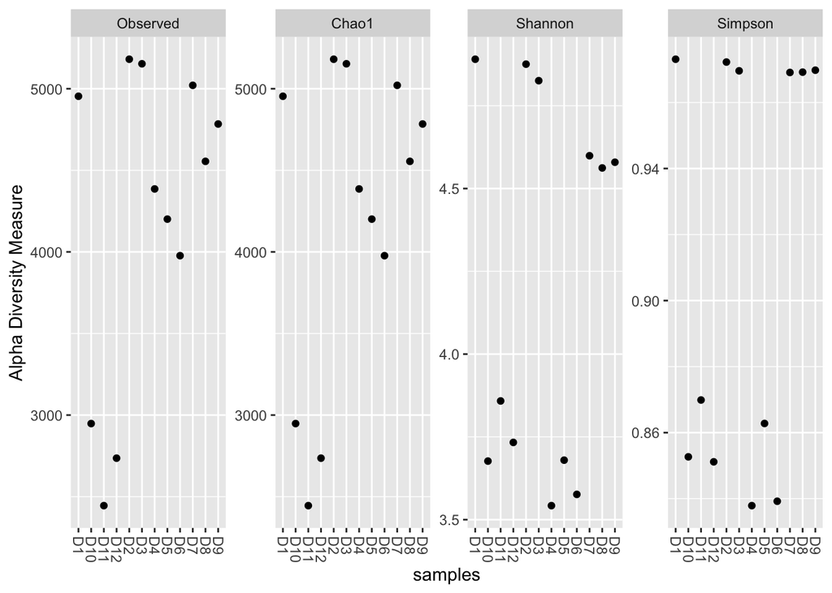

```r
plot_richness(physeq, measures=c("Observed", "Chao1", "Simpson", "Shannon"))
```

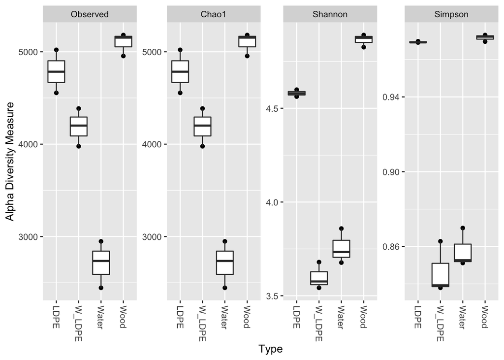

```r
plot_richness(physeq, x="Type", measures=c("Observed", "Chao1", "Simpson", "Shannon")) + geom_boxplot()
```

### Beta diversity

#### Species level

Bray-Curtis (raw counts):

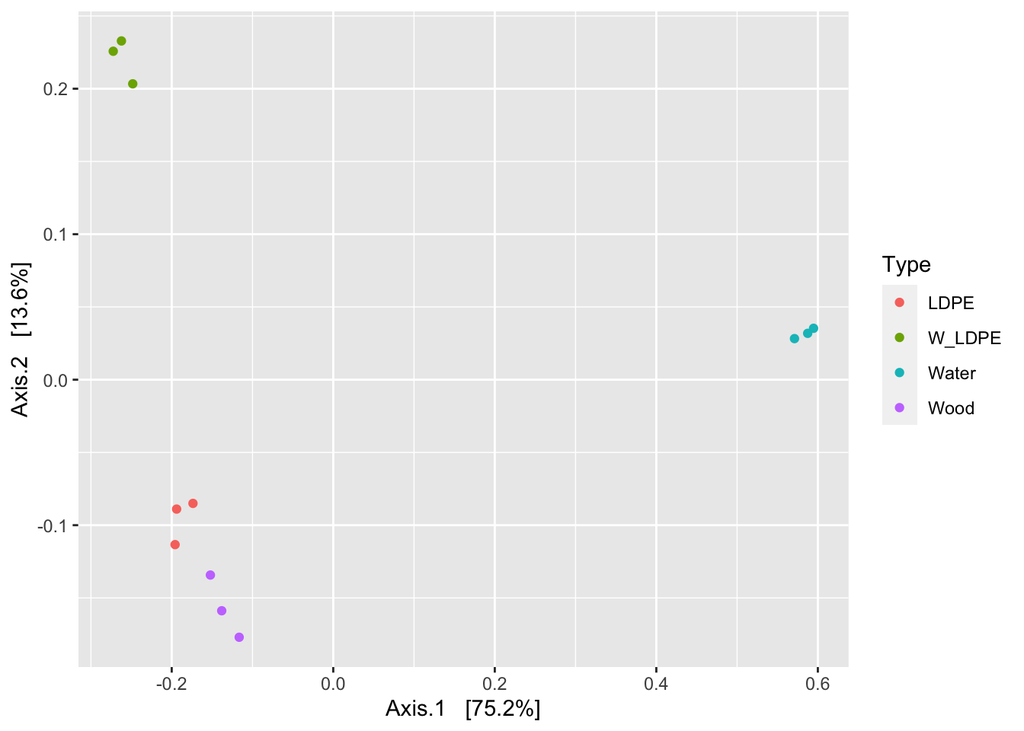

```r
ps.ord <- ordinate(physeq, "PCoA", "bray")
plot_ordination(physeq, ps.ord, type="samples", color="Type")
```

Bray-Curtis (relative abundance):

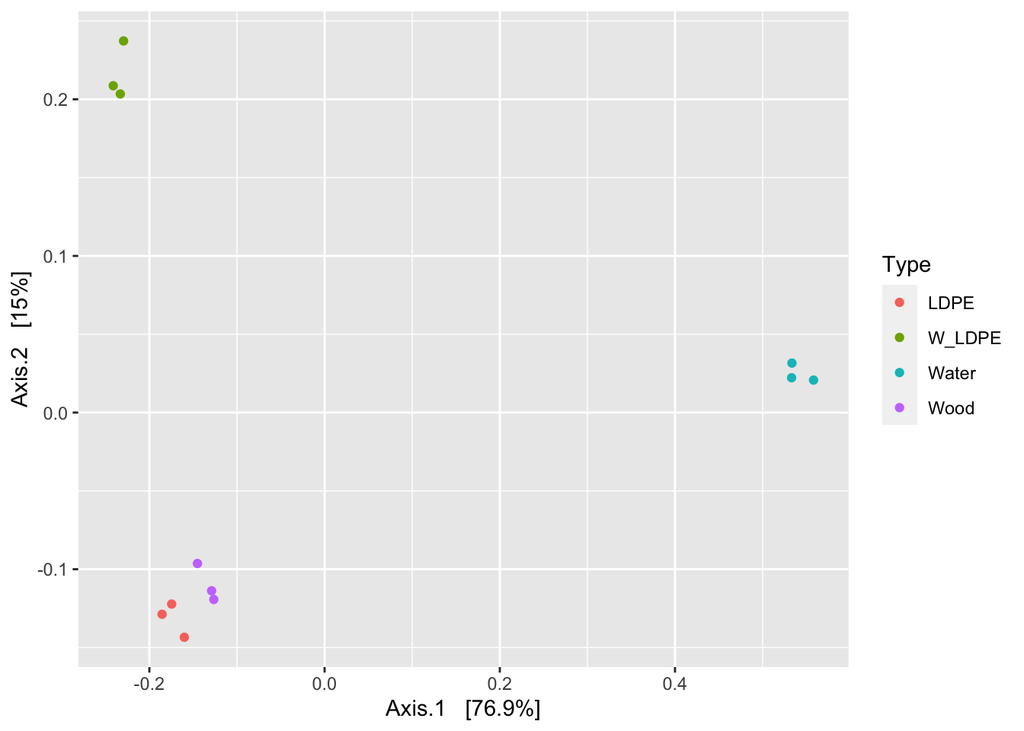

```r
ps.ord.ra <- ordinate(physeq_relabun, "PCoA", "bray")
plot_ordination(physeq_relabun, ps.ord.ra, type="samples", color="Type")
```

Bray-Curtis (rarefied):

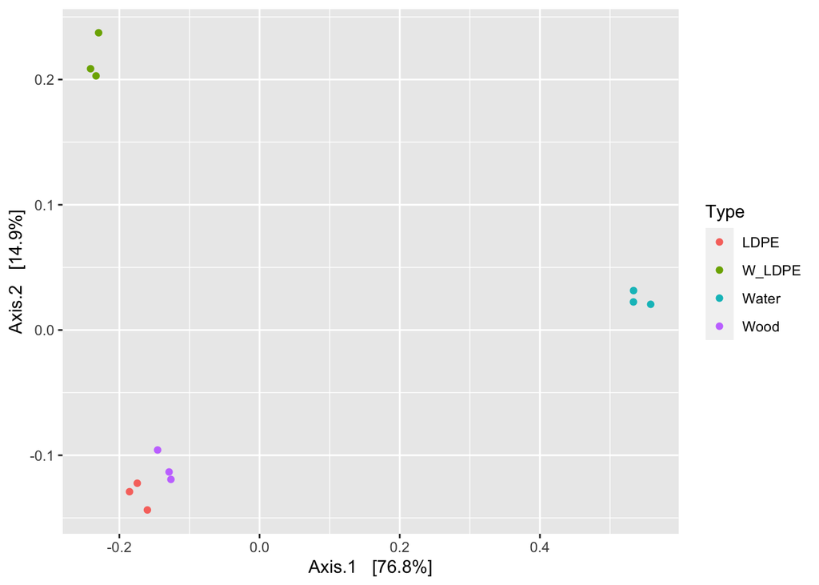

```r
ps.ord.rare <- ordinate(physeq_rare, "PCoA", "bray")
plot_ordination(physeq_rare, ps.ord.rare, type="samples", color="Type")
```

```r
distance <- phyloseq::distance(physeq_rare, method="bray", weighted=F)
print(adonis(distance ~ sample_data(physeq_rare)$Type))
```

```
##
## Call:
## adonis(formula = distance ~ sample_data(physeq_rare)$Type)
##
## Permutation: free
## Number of permutations: 999
##
## Terms added sequentially (first to last)
##
##                               Df SumsOfSqs MeanSqs F.Model      R2 Pr(>F)
## sample_data(physeq_rare)$Type  3   1.50193 0.50064  85.305 0.96969  0.001 ***
## Residuals                      8   0.04695 0.00587         0.03031
## Total                         11   1.54888                 1.00000
## ---
## Signif. codes:  0 '***' 0.001 '**' 0.01 '*' 0.05 '.' 0.1 ' ' 1
```

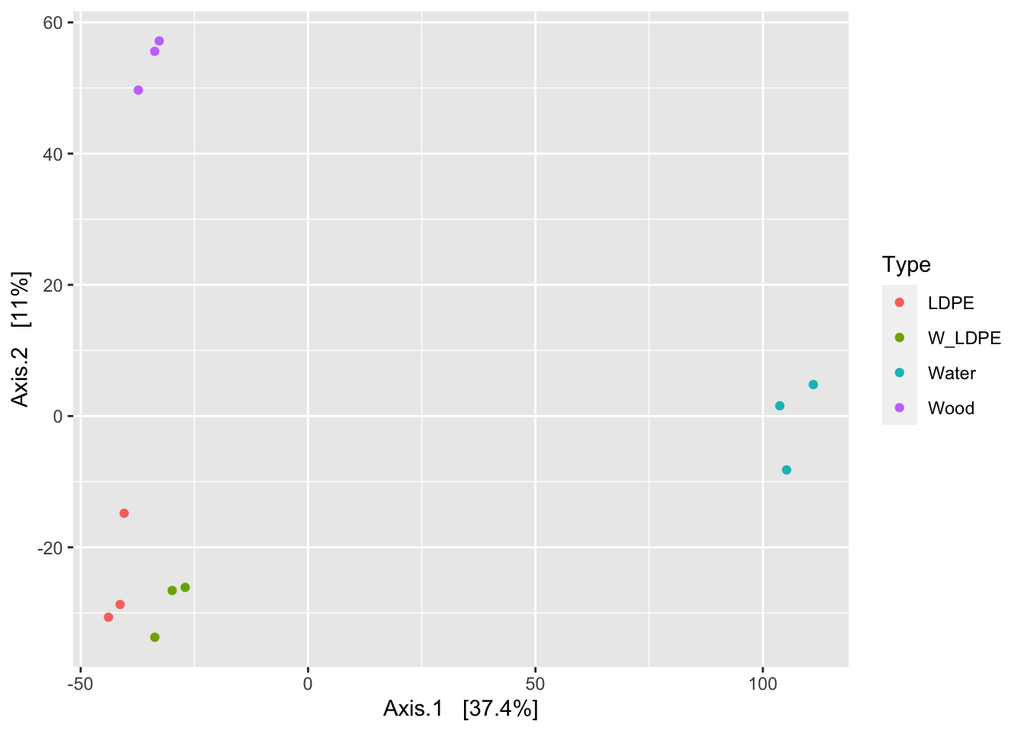

```r
ps.ord.clr <- ordinate(physeq_clr, "PCoA", "euclidean")
plot_ordination(physeq_clr, ps.ord.clr, type="samples", color="Type")
```

```r
distance <- phyloseq::distance(physeq_clr, method="euclidean", weighted=F)
print(adonis(distance ~ sample_data(physeq_clr)$Type))
```

```
##
## Call:
## adonis(formula = distance ~ sample_data(physeq_clr)$Type)
##
## Permutation: free
## Number of permutations: 999
##
## Terms added sequentially (first to last)
##
##                              Df SumsOfSqs MeanSqs F.Model      R2 Pr(>F)
## sample_data(physeq_clr)$Type  3     69065 23021.6  3.4515 0.56414  0.001 ***
## Residuals                     8     53361  6670.1         0.43586
## Total                        11    122426                 1.00000
## ---
## Signif. codes:  0 '***' 0.001 '**' 0.01 '*' 0.05 '.' 0.1 ' ' 1
```

#### Genus level

Bray-Curtis (raw counts):

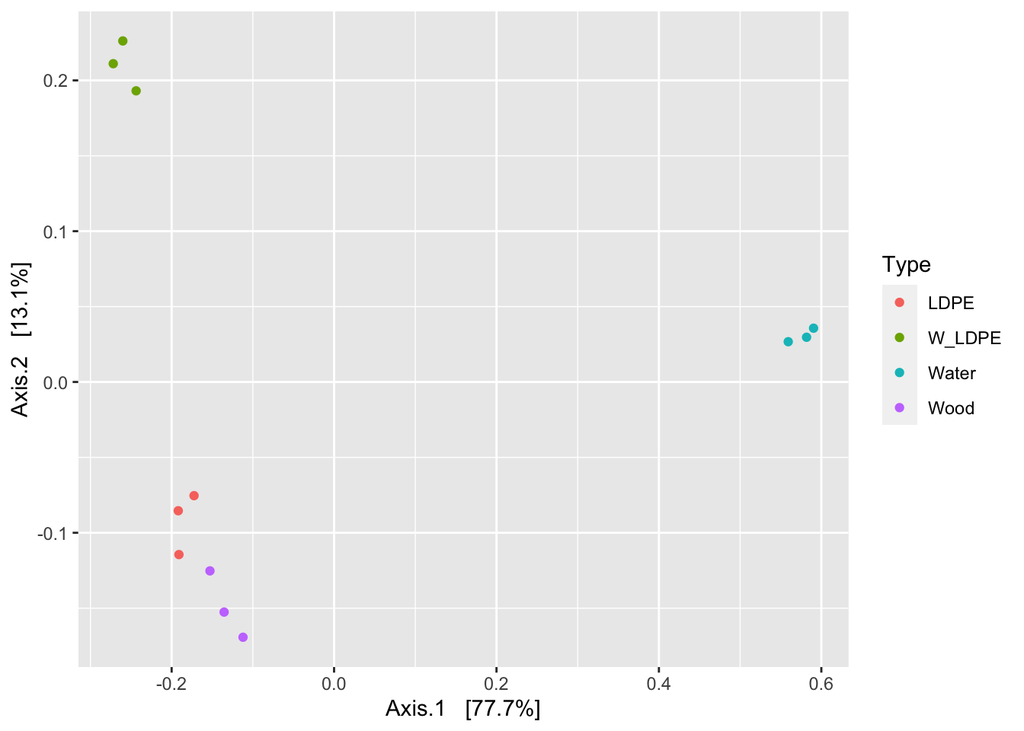

```r
rnk = "ta6"
ps.rank = tax_glom(physeq, taxrank=rnk, NArm=FALSE)
ps.ord <- ordinate(ps.rank, "PCoA", "bray")
plot_ordination(ps.rank, ps.ord, type="samples", color="Type")
```

Bray-Curtis (relative abundance):

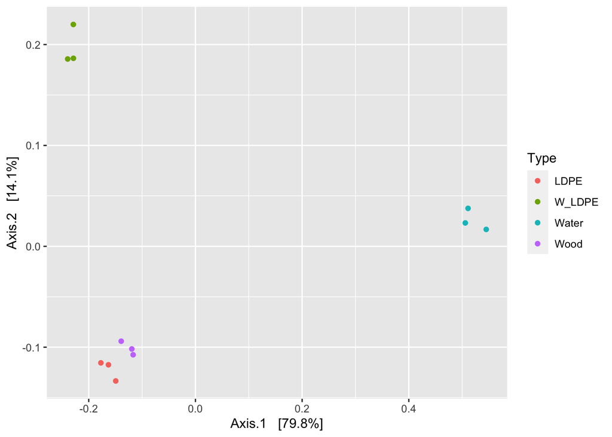

```r
rnk = "ta6"
ps.rank.ra = tax_glom(physeq_relabun, taxrank=rnk, NArm=FALSE)
ps.ord.ra <- ordinate(ps.rank.ra, "PCoA", "bray")
plot_ordination(ps.rank.ra, ps.ord.ra, type="samples", color="Type")
```

Bray-Curtis (rarefied):

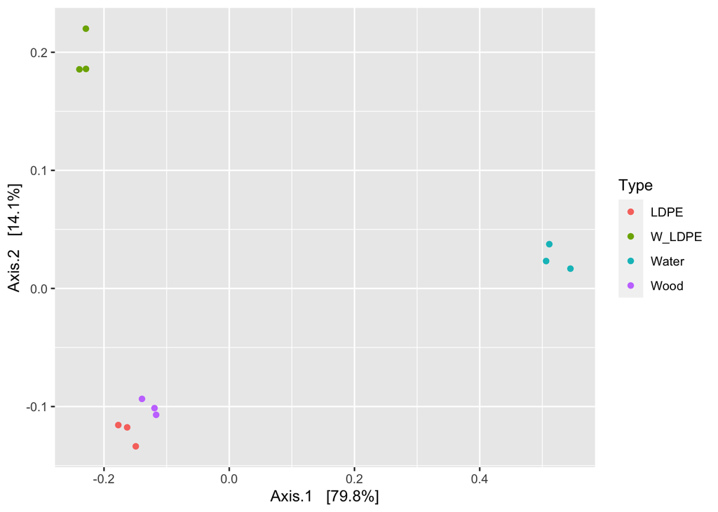

```r
rnk = "ta6"
ps.rank.rare = tax_glom(physeq_rare, taxrank=rnk, NArm=FALSE)
ps.ord.rank.rare <- ordinate(ps.rank.rare, "PCoA", "bray")
plot_ordination(ps.rank.rare, ps.ord.rank.rare, type="samples", color="Type")
```

```r
distance <- phyloseq::distance(ps.rank.rare, method="bray", weighted=F)
print(adonis(distance ~ sample_data(ps.rank.rare)$Type))
```

```
##
## Call:
## adonis(formula = distance ~ sample_data(ps.rank.rare)$Type)
##
## Permutation: free
## Number of permutations: 999
##
## Terms added sequentially (first to last)
##
##                                Df SumsOfSqs MeanSqs F.Model      R2 Pr(>F)
## sample_data(ps.rank.rare)$Type  3   1.35005 0.45002  106.41 0.97555  0.001 ***
## Residuals                       8   0.03383 0.00423         0.02445
## Total                          11   1.38388                 1.00000
## ---
## Signif. codes:  0 '***' 0.001 '**' 0.01 '*' 0.05 '.' 0.1 ' ' 1
```

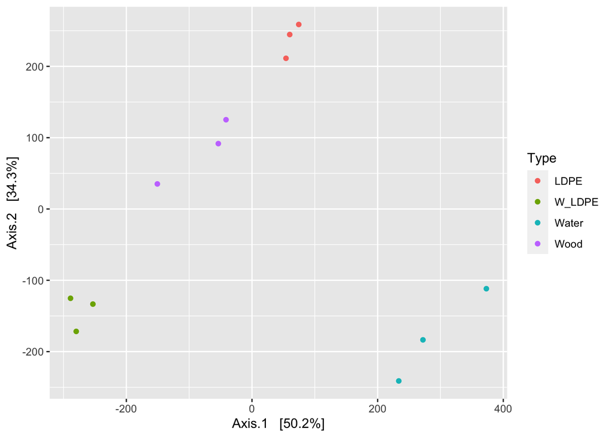

```r
rnk = "ta6"
ps.rank.clr = tax_glom(physeq_clr, taxrank=rnk, NArm=FALSE)
ps.ord.rank.clr <- ordinate(ps.rank.clr, "PCoA", "euclidean")
plot_ordination(ps.rank.clr, ps.ord.rank.clr, type="samples", color="Type")
```

```r
distance <- phyloseq::distance(ps.rank.clr, method="euclidean", weighted=F)
print(adonis(distance ~ sample_data(ps.rank.clr)$Type))
```

```
##
## Call:
## adonis(formula = distance ~ sample_data(ps.rank.clr)$Type)
##
## Permutation: free
## Number of permutations: 999
##
## Terms added sequentially (first to last)
##
##                               Df SumsOfSqs MeanSqs F.Model      R2 Pr(>F)
## sample_data(ps.rank.clr)$Type  3    957842  319281  24.343 0.90127  0.001 ***
## Residuals                      8    104928   13116         0.09873
## Total                         11   1062770                 1.00000
## ---
## Signif. codes:  0 '***' 0.001 '**' 0.01 '*' 0.05 '.' 0.1 ' ' 1
```

### Barplots

#### Phylum

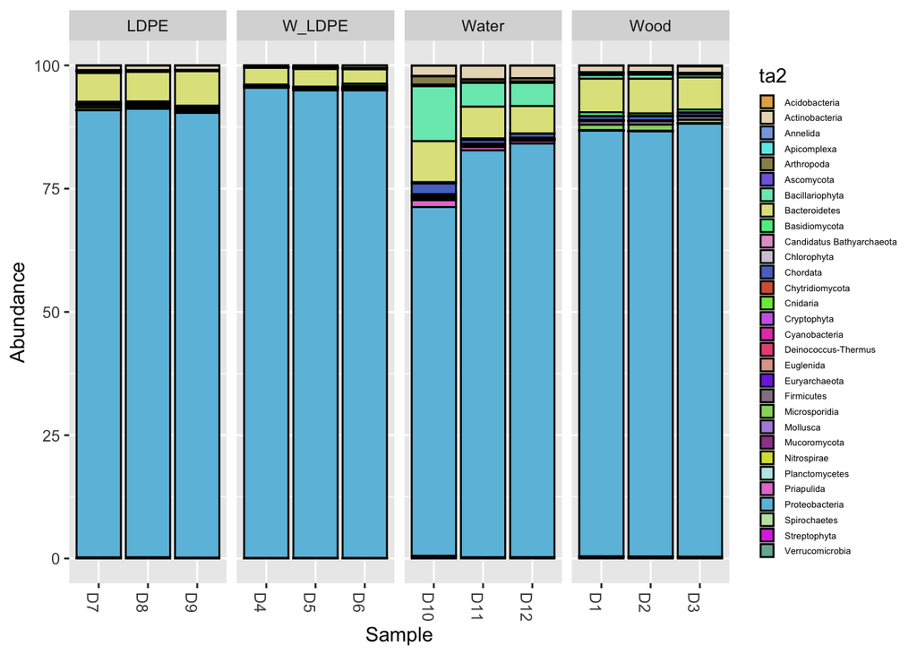

```r
options(warn = -1)
palette = distinctColorPalette(30)
rnk = "ta2"
ps.rank = tax_glom(physeq_relabun, taxrank=rnk, NArm=FALSE)
rank.sum = tapply(taxa_sums(ps.rank), tax_table(ps.rank)[, rnk], sum, na.rm=TRUE)
top30 = names(sort(rank.sum, TRUE))[1:30]
ps.rank = prune_taxa((tax_table(ps.rank)[, rnk] %in% top30), ps.rank)

plot_bar(ps.rank, fill=rnk) + facet_wrap(c(~Type), scales="free_x", nrow=1) + theme(legend.text=element_text(size=5), legend.key.size = unit(0.3, "cm")) + guides(fill=guide_legend(ncol=1)) + scale_fill_manual(values=palette)
```

#### Class

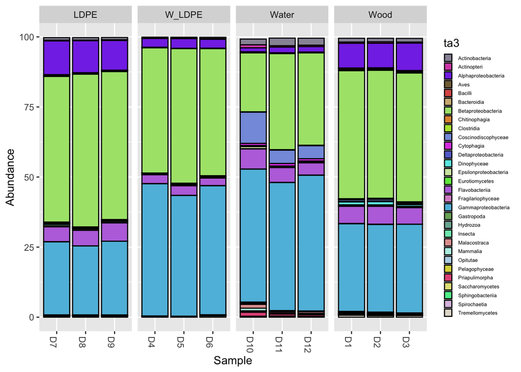

```r
options(warn = -1)
palette = distinctColorPalette(30)
rnk = "ta3"
ps.rank = tax_glom(physeq_relabun, taxrank=rnk, NArm=FALSE)
rank.sum = tapply(taxa_sums(ps.rank), tax_table(ps.rank)[, rnk], sum, na.rm=TRUE)
top30 = names(sort(rank.sum, TRUE))[1:30]
ps.rank = prune_taxa((tax_table(ps.rank)[, rnk] %in% top30), ps.rank)

plot_bar(ps.rank, fill=rnk) + facet_wrap(c(~Type), scales="free_x", nrow=1) + theme(legend.text=element_text(size=5), legend.key.size = unit(0.3, "cm")) + guides(fill=guide_legend(ncol=1)) + scale_fill_manual(values=palette)
```

#### Order

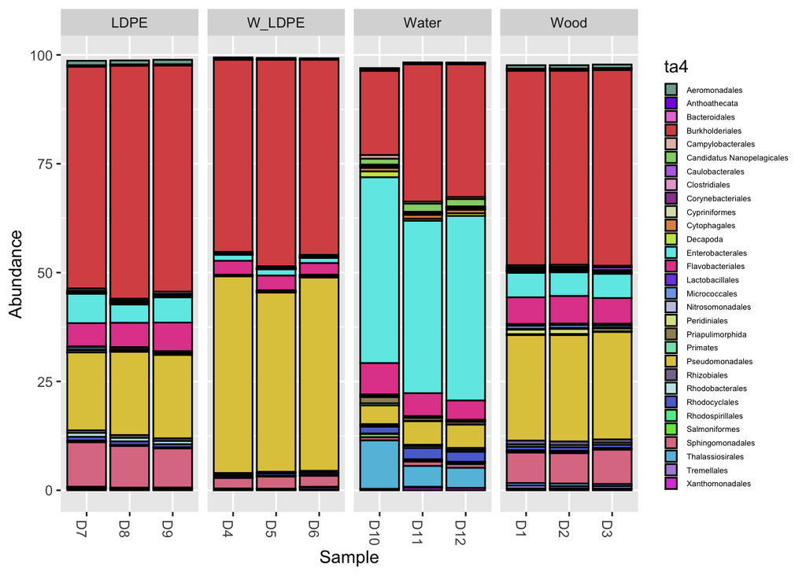

```r
options(warn = -1)
palette = distinctColorPalette(30)
rnk = "ta4"
ps.rank = tax_glom(physeq_relabun, taxrank=rnk, NArm=FALSE)
rank.sum = tapply(taxa_sums(ps.rank), tax_table(ps.rank)[, rnk], sum, na.rm=TRUE)
top30 = names(sort(rank.sum, TRUE))[1:30]
ps.rank = prune_taxa((tax_table(ps.rank)[, rnk] %in% top30), ps.rank)

plot_bar(ps.rank, fill=rnk) + facet_wrap(c(~Type), scales="free_x", nrow=1) + theme(legend.text=element_text(size=5), legend.key.size = unit(0.3, "cm")) + guides(fill=guide_legend(ncol=1)) + scale_fill_manual(values=palette)
```

#### Family

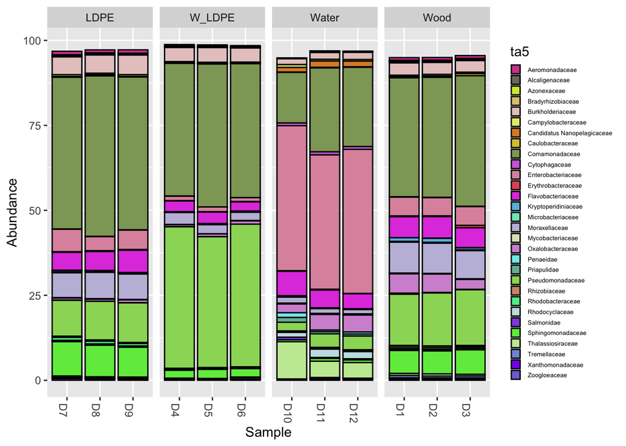

```r
options(warn = -1)
palette = distinctColorPalette(30)
rnk = "ta5"
ps.rank = tax_glom(physeq_relabun, taxrank=rnk, NArm=FALSE)
rank.sum = tapply(taxa_sums(ps.rank), tax_table(ps.rank)[, rnk], sum, na.rm=TRUE)
top30 = names(sort(rank.sum, TRUE))[1:30]
ps.rank = prune_taxa((tax_table(ps.rank)[, rnk] %in% top30), ps.rank)

plot_bar(ps.rank, fill=rnk) + facet_wrap(c(~Type), scales="free_x", nrow=1) + theme(legend.text=element_text(size=5), legend.key.size = unit(0.3, "cm")) + guides(fill=guide_legend(ncol=1)) + scale_fill_manual(values=palette)
```

#### Genus

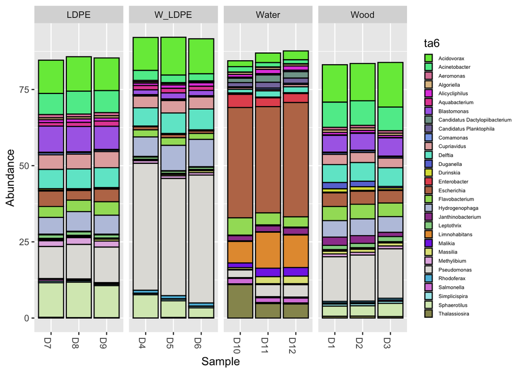

```r
options(warn = -1)
palette = distinctColorPalette(30)
rnk = "ta6"
ps.rank = tax_glom(physeq_relabun, taxrank=rnk, NArm=FALSE)
rank.sum = tapply(taxa_sums(ps.rank), tax_table(ps.rank)[, rnk], sum, na.rm=TRUE)
top30 = names(sort(rank.sum, TRUE))[1:30]
ps.rank = prune_taxa((tax_table(ps.rank)[, rnk] %in% top30), ps.rank)

plot_bar(ps.rank, fill=rnk) + facet_wrap(c(~Type), scales="free_x", nrow=1) + theme(legend.text=element_text(size=5), legend.key.size = unit(0.3, "cm")) + guides(fill=guide_legend(ncol=1)) + scale_fill_manual(values=palette)
```

#### Species

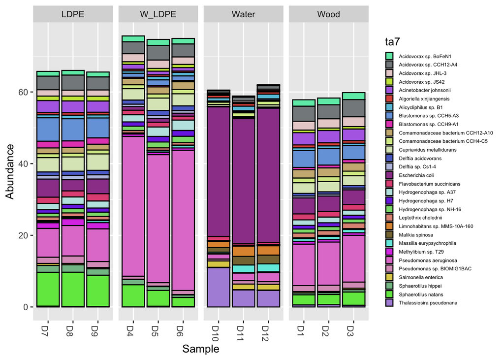

```r
options(warn = -1)
palette = distinctColorPalette(30)
rnk = "ta7"
ps.rank = tax_glom(physeq_relabun, taxrank=rnk, NArm=FALSE)
rank.sum = tapply(taxa_sums(ps.rank), tax_table(ps.rank)[, rnk], sum, na.rm=TRUE)
top30 = names(sort(rank.sum, TRUE))[1:30]
ps.rank = prune_taxa((tax_table(ps.rank)[, rnk] %in% top30), ps.rank)

plot_bar(ps.rank, fill=rnk) + facet_wrap(c(~Type), scales="free_x", nrow=1) + theme(legend.text=element_text(size=5), legend.key.size = unit(0.3, "cm")) + guides(fill=guide_legend(ncol=1)) + scale_fill_manual(values=palette)
```

### Differential abundance

LDPE vs Weathered LDPE

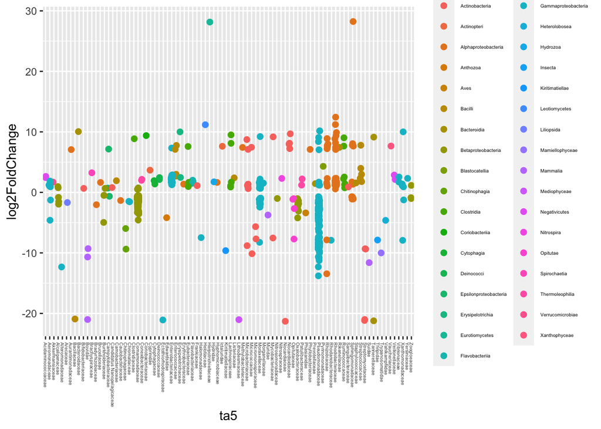

```r
options(warn = -1)
samples_keeping = c("D4", "D5", "D6", "D7", "D8", "D9")
physeq
ps = prune_samples(samples_keeping, physeq)
sample_data(ps)$Type <- as.factor(sample_data(ps)$Type)
ds = phyloseq_to_deseq2(ps, ~ Type)
ds = DESeq(ds)
alpha = 0.01
res = results(ds, contrast=c("Type", "LDPE", "W_LDPE"), alpha=alpha)
res = res[order(res$padj, na.last=NA), ]
res_sig = res[(res$padj < alpha), ]
res_sig = cbind(as(res_sig, "data.frame"), as(tax_table(ps)[rownames(res_sig), ], "matrix"))
res_sig
ggplot(res_sig, aes(x=ta5, y=log2FoldChange, color=ta3)) +
    geom_jitter(size=2, width = 0.2) +
    theme(axis.text.x = element_text(angle = -90, hjust = 0, vjust=0.5, size=4)) +
    theme(legend.text=element_text(size=4))
```

LDPE vs Wood

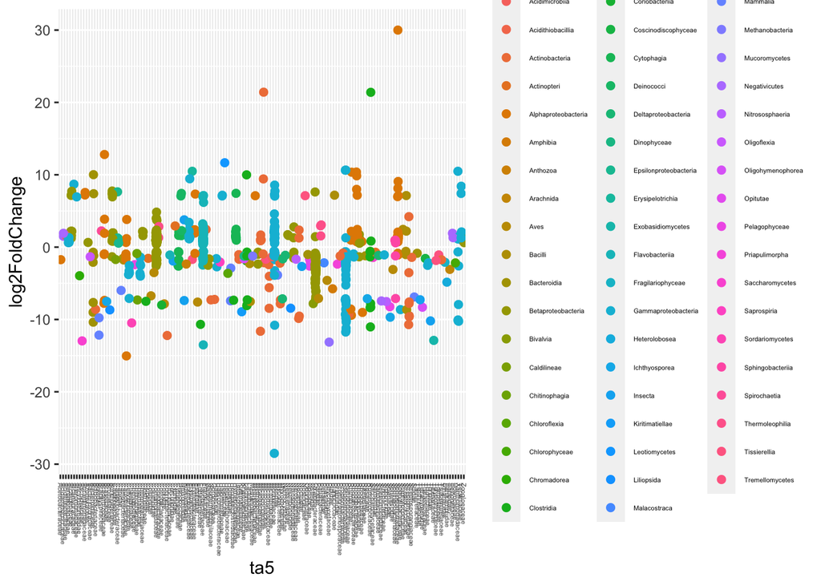

```r
options(warn = -1)
samples_keeping = c("D1", "D2", "D3", "D7", "D8", "D9")
physeq
ps = prune_samples(samples_keeping, physeq)
sample_data(ps)$Type <- as.factor(sample_data(ps)$Type)
ds = phyloseq_to_deseq2(ps, ~ Type)
ds = DESeq(ds)
alpha = 0.01
res = results(ds, contrast=c("Type", "LDPE", "Wood"), alpha=alpha)
res = res[order(res$padj, na.last=NA), ]
res_sig = res[(res$padj < alpha), ]
res_sig = cbind(as(res_sig, "data.frame"), as(tax_table(ps)[rownames(res_sig), ], "matrix"))
res_sig
ggplot(res_sig, aes(x=ta5, y=log2FoldChange, color=ta3)) +
    geom_jitter(size=2, width = 0.2) +
    theme(axis.text.x = element_text(angle = -90, hjust = 0, vjust=0.5, size=4)) +
    theme(legend.text=element_text(size=4))
```